# EDA SIP

## O que são os dados

```
## Observations: 12,299
## Variables: 17
## $ TaskNumber           <chr> "1735", "1742", "1971", "2134", "2251", "2283"...
## $ Summary              <chr> "Flag RI on SCM Message Summary screen using m...
## $ Priority             <dbl> 1, 1, 2, 5, 10, 1, 5, 5, 6, 5, 2, 1, 3, 1, 1, ...
## $ RaisedByID           <chr> "58", "58", "7", "50", "46", "13", "13", "13",...
## $ AssignedToID         <chr> "58", "42", "58", "42", "13", "13", "13", "58"...
## $ AuthorisedByID       <chr> "6", "6", "6", "6", "6", "58", "6", "6", "6", ...
## $ StatusCode           <chr> "FINISHED", "FINISHED", "FINISHED", "FINISHED"...
## $ ProjectCode          <chr> "PC2", "PC2", "PC2", "PC2", "PC2", "PC9", "PC2...
## $ ProjectBreakdownCode <chr> "PBC42", "PBC21", "PBC75", "PBC42", "PBC21", "...
## $ Category             <chr> "Development", "Development", "Operational", "...
## $ SubCategory          <chr> "Enhancement", "Enhancement", "In House Suppor...
## $ HoursEstimate        <dbl> 14.00, 7.00, 0.70, 0.70, 3.50, 7.00, 7.00, 7.0...
## $ HoursActual          <dbl> 1.75, 7.00, 0.70, 0.70, 3.50, 7.00, 7.00, 7.00...
## $ DeveloperID          <chr> "58", "42", "58", "42", "13", "13", "43", "58"...
## $ DeveloperHoursActual <dbl> 1.75, 7.00, 0.70, 0.70, 3.50, 7.00, 7.00, 7.00...
## $ TaskPerformance      <dbl> 12.25, 0.00, 0.00, 0.00, 0.00, 0.00, 0.00, 0.0...
## $ DeveloperPerformance <dbl> 12.25, 0.00, 0.00, 0.00, 0.00, 0.00, NA, 0.00,...
```

## Entendendo os dados

Data summary

| Name | Piped data |
| --- | --- |
| Number of rows | 12299 |
| Number of columns | 4 |
| _______________________ |  |
| Column type frequency: |  |
| character | 2 |
| numeric | 2 |
| ________________________ |  |
| Group variables | None |

**Variable type: character**

| skim_variable | n_missing | complete_rate | min | max | empty | n_unique | whitespace |
| --- | --- | --- | --- | --- | --- | --- | --- |
| ProjectCode | 0 | 1 | 3 | 4 | 0 | 20 | 0 |
| TaskNumber | 0 | 1 | 4 | 5 | 0 | 10266 | 0 |

**Variable type: numeric**

| skim_variable | n_missing | complete_rate | mean | sd | p0 | p25 | p50 | p75 | p100 | hist |
| --- | --- | --- | --- | --- | --- | --- | --- | --- | --- | --- |
| HoursEstimate | 0 | 1 | 10.15 | 28.84 | 0.01 | 1 | 3 | 7.0 | 910.00 | ▇▁▁▁▁ |
| HoursActual | 0 | 1 | 13.18 | 68.72 | 0.01 | 1 | 3 | 8.5 | 2490.16 | ▇▁▁▁▁ |

Temos 20 projetos, com 12299 estimativas_raw. Não há apenas uma estimativa por tarefa, já que há apenas 10266 valores distintos de `TaskNumber`.

```
## # A tibble: 1,384 x 2
## # Groups:   TaskNumber [1,384]
##    TaskNumber     n
##    <chr>      <int>
##  1 10605          8
##  2 6889           8
##  3 10089          7
##  4 10974          7
##  5 11056          7
##  6 11270          7
##  7 13124          7
##  8 13190          7
##  9 13253          7
## 10 3812           7
## # ... with 1,374 more rows
```

### 1 estimativa por task

Para nossa análise, usaremos uma estimativa por task. Caso haja mais de uma usaremos a média das estimativas_raw:

### Dados por time

```
## # A tibble: 6 x 8
##   ProjectCode TaskNumber Category Priority Summary HoursEstimate HoursActual
##   <chr>       <chr>      <chr>       <dbl> <chr>           <dbl>       <dbl>
## 1 PC1         11276      Managem~        3 Meetin~            14        10
## 2 PC1         11286      Develop~        1 CCC Fi~            35        22.2
## 3 PC1         11294      Develop~        1 Develo~            21        44
## 4 PC1         11306      Develop~        1 CCC me~            14         9
## 5 PC1         11313      Develop~        1 CCC Zo~            28         7
## 6 PC1         11316      Develop~        1 Zone C~            14        27.5
## # ... with 1 more variable: DeveloperPerformance <dbl>
```

```
## # A tibble: 6 x 4
##   ProjectCode  devs erro_medio_abs estimativas
##   <chr>       <int>          <dbl>       <int>
## 1 PC1             4          18.5           54
## 2 PC10            4          35.9           73
## 3 PC11           11           4.60         292
## 4 PC12            3           8.27          54
## 5 PC13            6           8.50         171
## 6 PC14           11          90.4          105
```

## Qual a relação entre as estimativas e horas reais tomadas na empresa como um todo e em diferentes categorias de tarefa?

Detalhando um pouco mais os dados para entender a distribuição para as variáveis HoursEstimate e HoursActual, temos:

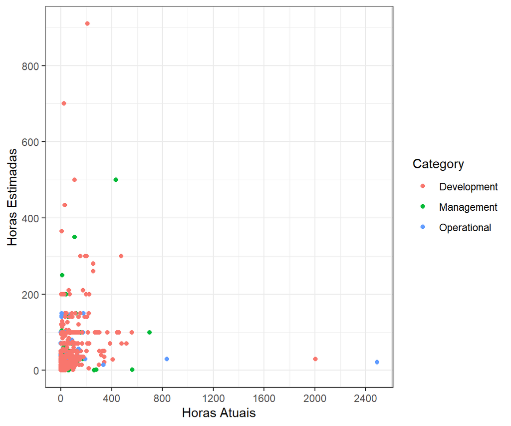

Como podemos ver, a maior parte dos registro para horas estimadas se concentram entre 0 e 200, enquanto que para horas atuais se concentram entre 0 e 400, sendo assim, vamos eliminiar os dados fora destes intervalos.

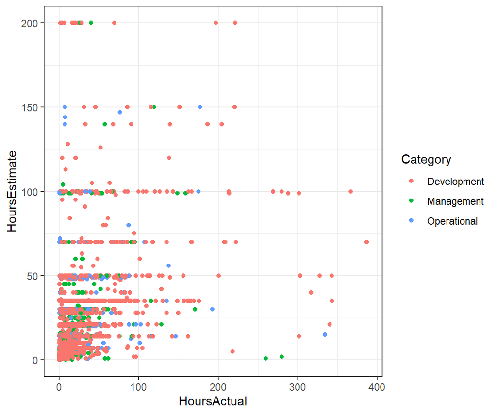

Mesmo com a filtragem inicial, como podemos ver nos dados apresentados abaixo, existe uma grande presença de outliers nas 3 categorias de tarefa existentes, tanto para horas estimadas quanto para horas reais. Sendo assim, vamos desconsiderar o coeficiente de Pearson para a análise de correlação.

```
##  HoursEstimate
##  Min.   :  0.010
##  1st Qu.:  1.000
##  Median :  2.500
##  Mean   :  8.174
##  3rd Qu.:  7.000
##  Max.   :200.000
```

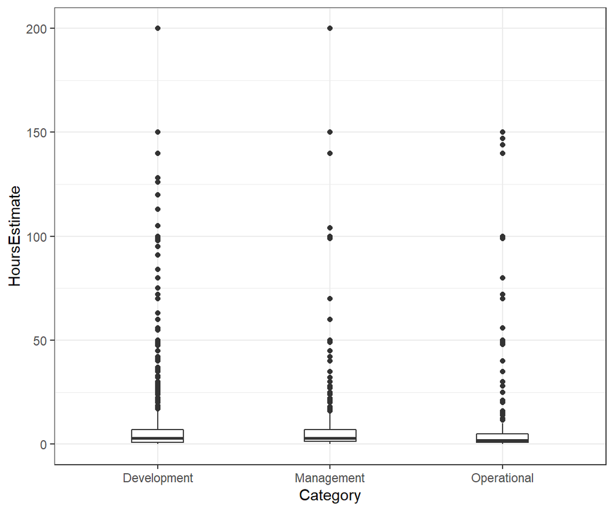

```
##   HoursActual
##  Min.   :  0.010
##  1st Qu.:  1.000
##  Median :  2.500
##  Mean   :  8.112
##  3rd Qu.:  7.000
##  Max.   :386.840
```

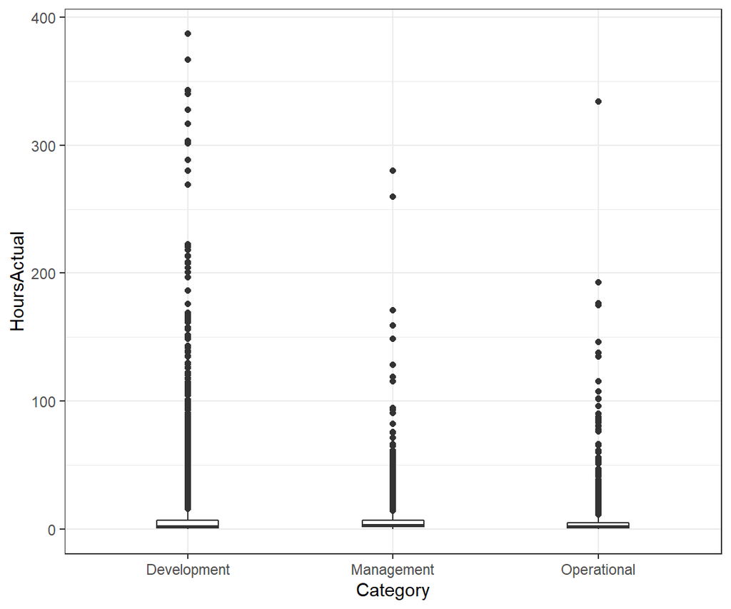

Analisando a relação como um todo, sem restrição de categorias, temos:

```
## # A tibble: 1 x 2
##   spearman kendall
##      <dbl>   <dbl>
## 1    0.825   0.695
```

Com isso, tanto o coeficiente de Spearman quanto o de Kendall indicam que há uma forte correlação positiva entre as variáveis, isto é, a medida que se aumentam as horas estimadas, também aumentam as horas reais de execução da tarefa. A partir disto é possível concluir que, no geral, as estimativas do tempo de conclusão das atividade estão de acordo com o tempo que foi necessário para concluí-las.

Separando as atividades de acordo com as 3 categorias existentes temos:

1.Development:

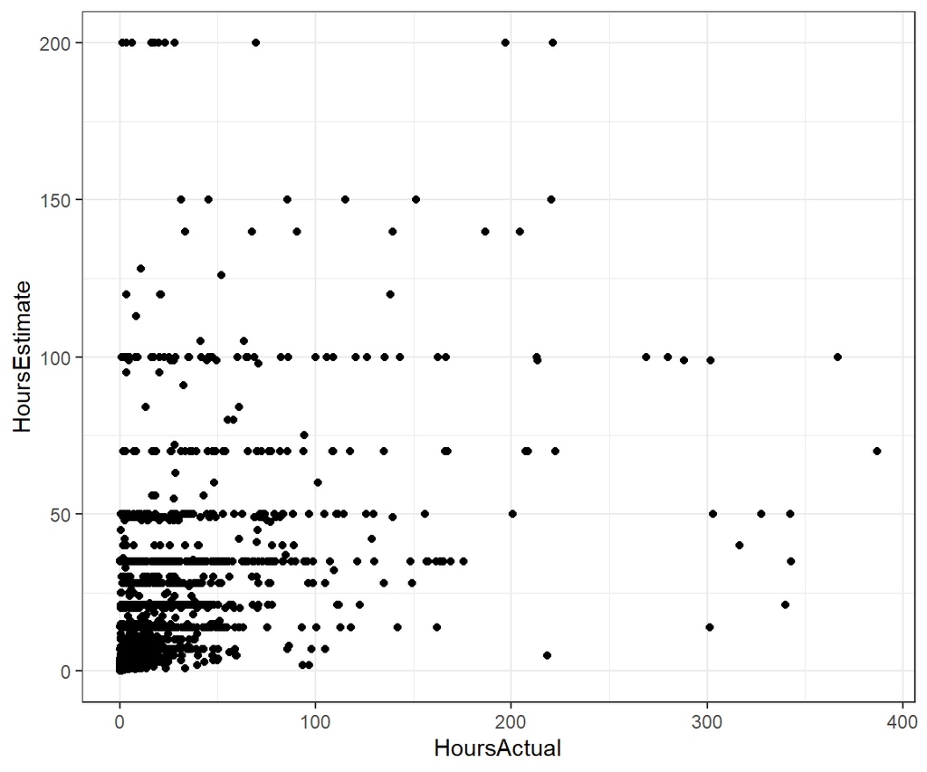

```
## # A tibble: 1 x 2
##   spearman kendall
##      <dbl>   <dbl>
## 1    0.833   0.699
```

2. Management:

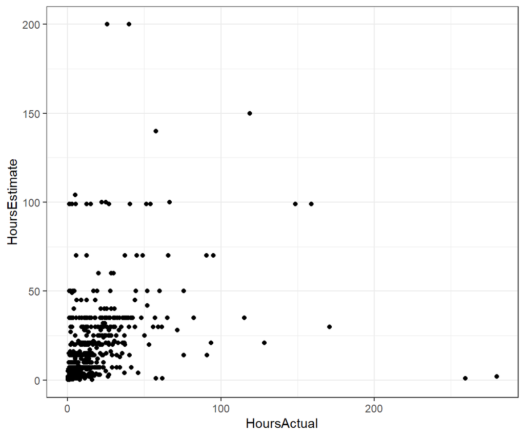

```
## # A tibble: 1 x 2
##   spearman kendall
##      <dbl>   <dbl>
## 1    0.753   0.635
```

3. Operational:

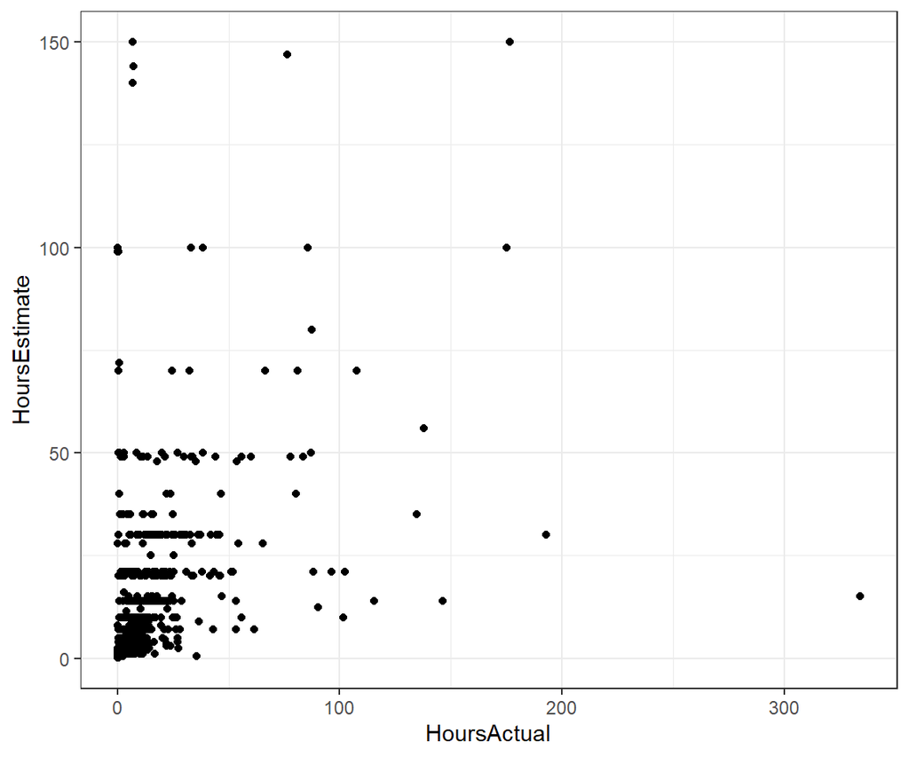

```
## # A tibble: 1 x 2
##   spearman kendall
##      <dbl>   <dbl>
## 1    0.841   0.729
```

Para as 3 categorias podemos perceber que há uma relação positiva forte entre as variáveis horas estimadas e horas reais, seguindo o comportamento geral.

Sendo assim, podemos concluir que na maioria dos casos, independente da categoria, o prazo de execução das tarefas estão recebendo estimativas que seguem a realidade.

## Equipes com mais desenvolvedores produzem estimativas com mais ou menos erro que equipes menores?

Analisando a distribuição das variáveis, temos:

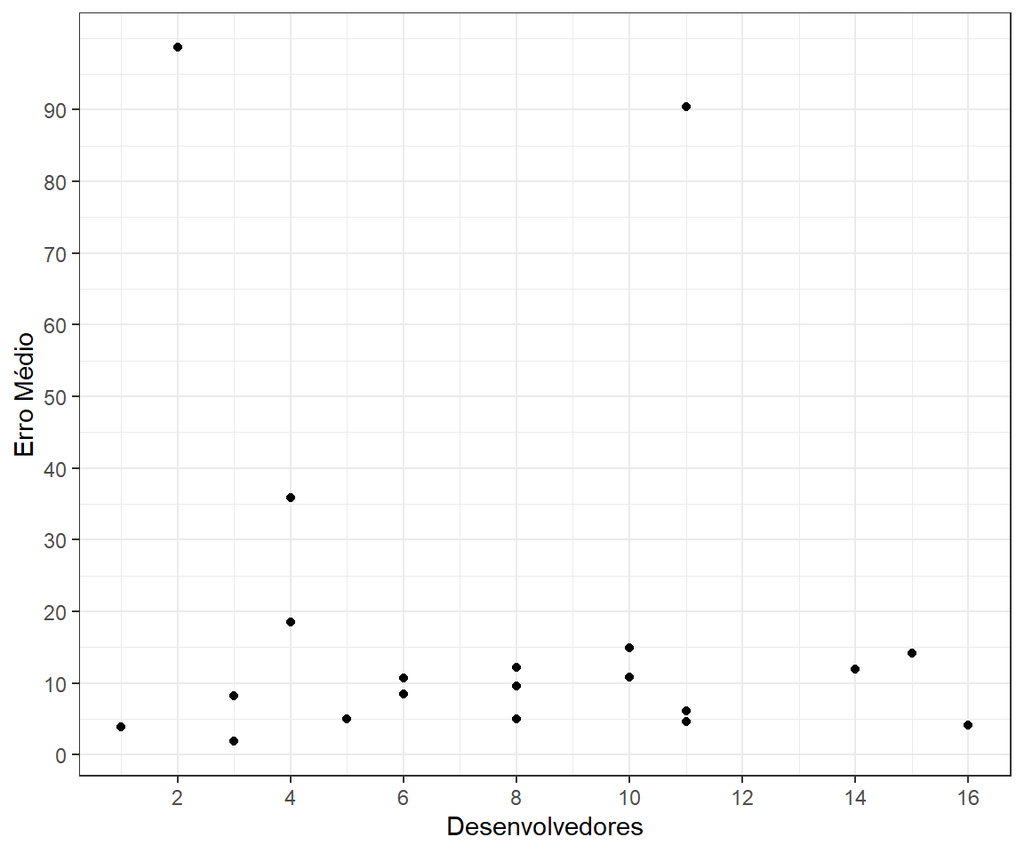

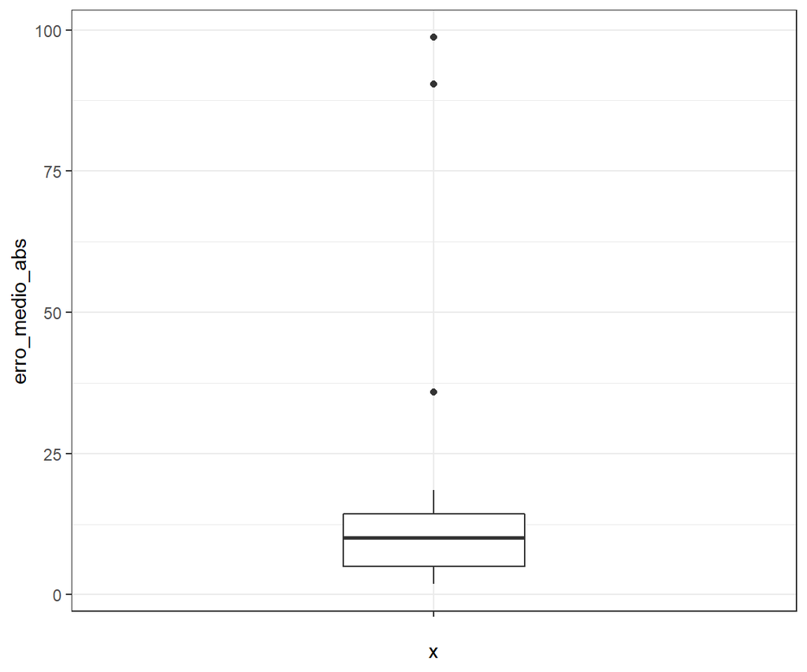

Nos gráficos acima, podemos perceber a presença de 3 outliers que podem atrapalhar a análise dos dados, sendo assim, vamos excluí-los.

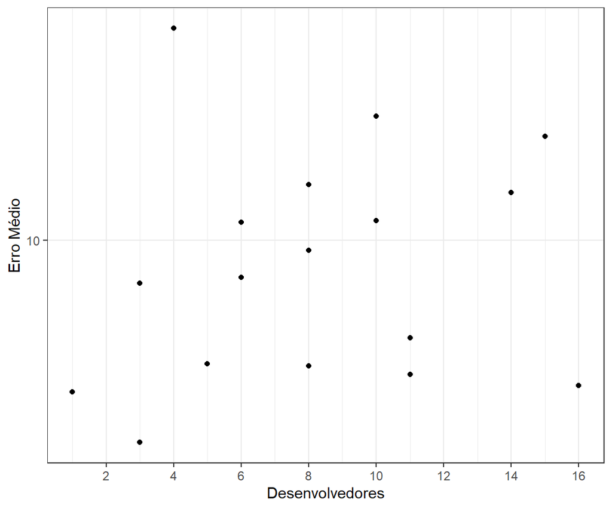

Analisando a correlação entre essas duas variáveis, temos:

```
## # A tibble: 1 x 3
##   pearson spearman kendall
##     <dbl>    <dbl>   <dbl>
## 1   0.172    0.229   0.174
```

Sendo assim, com base nos coeficientes de correlação calculados, temos que não há uma relação entre tamanho da equipe e erros de estimativa, não sendo possível afirmar que equipes com mais desenvolvedores comentem mais ou menos erros que equipe menores.